# Analyzing the affect of Redlining on LAs reported bird biodiversity

{Hazel Vaquero}

2023-12-15

# Background Information

Redlining is a historical practice with racial undertones incorporated in 1930 by the Home Owners’ Loan Corporation (HOLC), as part of the New Deal. Neighborhoods were rated based on their perceived safety for real estate investment. Their ranking system, A (green), B (blue), C (yellow), D (red)) was then used to block access to loans for home ownership. This practice targeted and discriminated against minority residents. This unjust practice halted economic development and created environmental injustice[^1].

A recent study found that redlining is also affecting the observations of biodiversity[^2]. Ellis-Soto and co-authors found that redlined neighborhoods remain the most under sampled areas across 195 US cities. Observation like these rely on community or citizen scientist to contribute and identify species. The gap in data is concerning because conservation decisions are made based on these data.

Specifically in LA county, neighborhoods in redlining district view less biodiversity in birds[^3]. These areas have fewer canopy covers which leads to only certain birds more resilient to urban life to be present.

# Data

EJScreen

The Environmental Protection Agency’s Environmental Justice Screening and Mapping Tool spatial data was used to access data on income, health, and race for LA county. The EJScreen uses data that is publicly available to be used to analyze environmental justice across the country. There are potential limitations to this dataset: uncertainty in estimates for smaller areas, does not cover all relevant issues, and environmental indicators are only screening-level proxies for actual health impacts.

EJScreen provides data on environmental and demographic information for the US at the Census tract and [block group](https://en.wikipedia.org/wiki/Census_block_group) levels.

Mapping Inequality

The redlining maps were obtain from the [Digital Scholarship Lab](https://dsl.richmond.edu/). Researchers at the University of Richmond have digitized maps and information from the HOLC as part of the [Mapping Inequality](https://dsl.richmond.edu/panorama/redlining/#loc=5/39.1/-94.58) project. It was directly accessed from the site and downloaded as a GeoJSn

Information on the data can be found [here](https://dsl.richmond.edu/panorama/redlining/#loc=5/39.1/-94.58&text=downloads)[^4].

Global Biodiversity Information Facility

The community scientist bird observations data was downloaded as a ShapeFile from the Global Biodiversity Information Facility. Observations include the location, date, and species observed..

# Analysis:

My initial analysis is to get a scope of LA county economic and racial distribution. Using the EJScreen I am interested in analyzing Census block groups that:

```
-   are above the 95th percentile of national values for wastewater
    discharge

-   have less than 5% of the population are considered low-income

-   above the 80th percentile for Particular Matters 2.5

-   above the 80th percentile for Superfund proximity
```

Building on to these I will also analyze the economic and health disparity in historical redlined areas. How does redlining areas relate to:

- rates of low income
- percentile for Particular Matter (PM) 2.5
- percentile for low life expectancy
- percentile for air toxic cancer risk

## Import Libraries

```r
library(tmap)
library(tidyverse)
library(sf)
library(dplyr)
library(ggplot2)
library(gt)
library(magrittr)
library(formattable)
library(janitor)
```

## Import data

Import our EJScreen, Redlining GeoJSn data, and bird observations.

```r
# Import EJ Screen data
ej_screen <-
  st_read("data/EJSCREEN_2023_BG_StatePct_with_AS_CNMI_GU_VI.gdb") %>%
  clean_names() # clean column names
# Import redlining information for Los Angeles

LA_redlining <- st_read("https://dsl.richmond.edu/panorama/redlining/static/downloads/geojson/CALosAngeles1939.geojson") %>%
  st_make_valid() # validates geometry
# Import bird observation data
bird_observation <- st_read("data/gbif-birds-LA/gbif-birds-LA.shp")
```

## Prepare data

Let’s prepare the data for Los Angeles county and Redlining for analysis.

```r
# Filter to Los Angeles and remove NA values
los_angeles <- ej_screen %>% filter(cnty_name == "Los Angeles County",
                                    !is.na(p_pwdis))

# Update CRS of Los Angeles and Redlining
if (st_crs(los_angeles) != st_crs(LA_redlining)){
  LA_redlining <- st_transform(LA_redlining, crs = st_crs(los_angeles))
}

# Check if CRS are equal
st_crs(los_angeles) == st_crs(LA_redlining)
```

### EJScreen parameters analysis

The first parameter we are interested in is the census block groups that are above the 95th percentile of national values for wastewater discharge.

Once filtered we can map our results

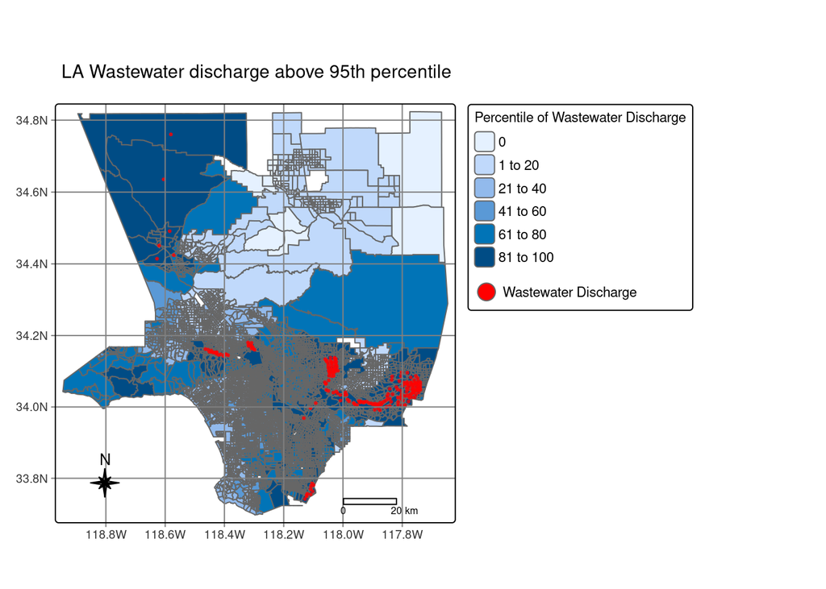

```r
# Los Angles centroid base
tm_shape(los_angeles) +
  tm_polygons(fill = 'p_pwdis',
              title = "Percentile of Wastewater Discharge") +
  tm_shape(los_angeles_water) + #wastewater discharge centroid
  tm_dots(
    'p_pwdis',
    alpha = 0.7,
    title.size = "A",
    col = 'red',
    title = 'A'
  ) +
  tm_layout(
    legend.outside = FALSE,
    main.title = 'LA Wastewater discharge above 95th percentile',
    main.title.size = 10,
    legend.text.size = 0.7,
    legend.title.size = 0.7
  ) +
  tm_compass(type = "8star",
             size = 1.5,
             position = c("left", "bottom")) +
  tm_graticules() +
  tm_scale_bar(position = c(0.7, 0)) +
  tm_add_legend(labels = 'Wastewater Discharge',
                fill = 'red')
```

The next environmental justice parameters I want to analyze are what percentage of census block groups have less than 5% of the population considered low income?

```r
# filter census blocks
low_income_5 <- los_angeles %>%
  select(lowincpct) %>%
  filter(lowincpct < .05)


# Percent of the population is low income
paste(round(nrow(low_income_5)/nrow(los_angeles) * 100,3), "% of the population is low income")
```

```
## [1] "5.896 % of the population is low income"
```

As well as, what percentage of census block are above the 80th percentile for PM 2.5 and Superfund proximity.

```r
# filter PM 2.5 and Superfund proximity
pm2_5 <- los_angeles %>% select(p_pm25, p_pnpl) %>%
  filter(p_pm25 > 80 & p_pnpl > 80)

# Percent of census blocks
paste(round(nrow(pm2_5)/nrow(los_angeles)*100,3), "% of the census block are
above the 80th percentile for PM 2.5 and Superfund proximity")
```

```
## [1] "17.428 % of the census block are \nabove the 80th percentile for PM 2.5 and Superfund proximity"
```

### Historical redlining paramter analysis

Next let’s make a map of the historical redlining boundaries, colored by HOLC grade for LA county.

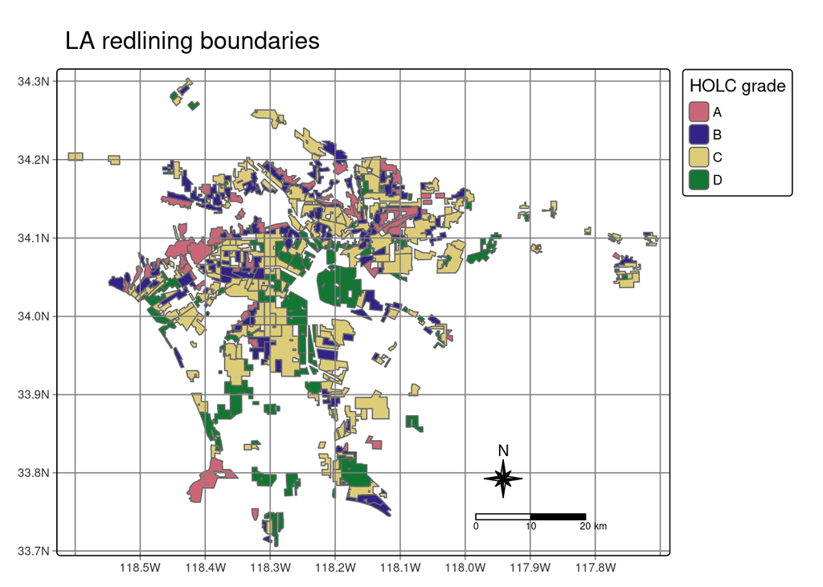

```r
tm_shape(LA_redlining) +
  tm_polygons("holc_grade",
              title = "HOLC grade") +
  tm_compass(type = "8star",
             size = 2) +
  tm_graticules() +
  tm_scale_bar() +
  tm_layout(main.title = "LA redlining boundaries")
```

First we need to identify the number of sensus block groups that fall within areas with HOLC grades.

```r
# Filter LA EJScreen for redlining data

redlining_blocks <- los_angeles %>%
  st_filter(y = LA_redlining, .predicate = st_intersects)

# Census blocks
paste(nrow(redlining_blocks),"census block groups")
```

```
## [1] "3945 census block groups"
```

Combining the Redlining and EJScreen data I am interested in analyzing how current conditions are within historical redlining categories. I will analyze the mean for: -% low income - percentile for particulate Matter 2. - percentile for low life expectancy - percentile for air toxics cancer risk

```r
# Combine LA EJScreen and Redlining data for LA county

LA <- st_intersection(los_angeles, LA_redlining)

# Find the mean of % low income within historical redlining categories
mean_table <- LA %>%
  group_by(holc_grade) %>%
  summarise(mean_Low_Income = mean(lowincpct, na.rm = TRUE),
            mean_particular_matter = mean(p_pm25, na.rm = TRUE),
            mean_low_life_expectancy = mean(p_lifeexppct, na.rm = TRUE),
            mean_cancer_risk = mean(p_cancer, na.rm = TRUE)
            ) %>% st_drop_geometry() # drop geometry

# Table with values
formattable(mean_table)
```

| holc_grade | mean_Low_Income | mean_particular_matter | mean_low_life_expectancy | mean_cancer_risk |
| --- | --- | --- | --- | --- |
| A | 0.1504211 | 72.12081 | 23.69515 | 44.01119 |
| B | 0.2419799 | 76.33145 | 37.37701 | 47.69579 |
| C | 0.3412925 | 78.82744 | 47.88598 | 54.56703 |
| D | 0.3917344 | 80.23958 | 53.05937 | 56.52459 |

For all of the variables, they have a higher mean in Holc Grades C and D. Areas that were deemed “Definitely Declining”(C) and “Hazardous”(D) have higher mean values in % low income, particular Matter 2.5, percentile for low life expectancy,and percentile for air toxic cancer risk. Areas C and D have worst quality of life.

### Bird observatory

The final analysis this notebook will cover is analyze if areas in historical redlining report fewer observations of birds?

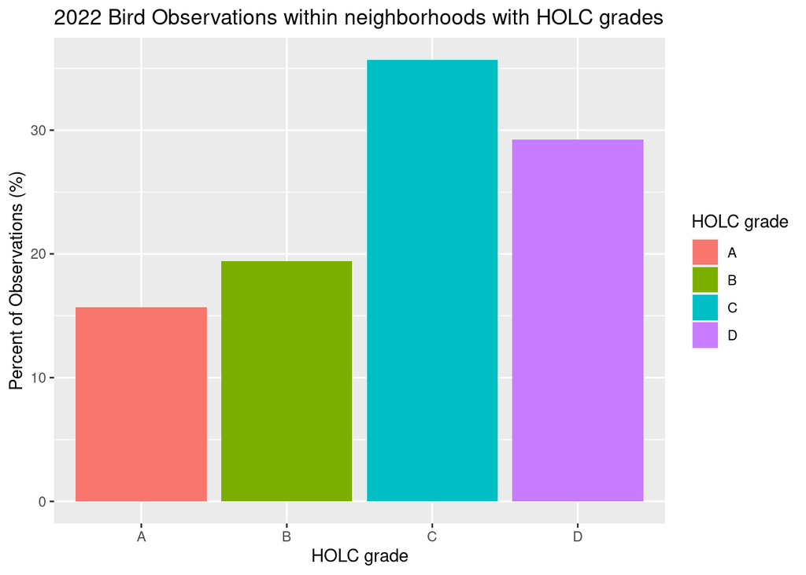

```r
# Transform bird observation CRS to redlining
bird_observation <- st_transform(bird_observation,crs = st_crs(LA_redlining))

# Intersect red lining map and bird observation
la_birds <- st_intersection(x = LA_redlining, y = bird_observation)

# Percent observations of birds in HOLC grads
birds <- la_birds %>%
  filter(year == 2022) %>%
  group_by(holc_grade) %>%
  summarise(count = n()) %>%
  mutate("sum" = sum(count),
         "percent" = count / sum * 100)

## Plot birds observations
ggplot(birds) +
  geom_col(aes(x = holc_grade,
               y= percent,
               fill = holc_grade)) +
  labs(x = "HOLC grade",
       y = "Percent of Observations (%)",
       title = "2022 Bird Observations within neighborhoods with HOLC grades",
       fill = "HOLC grade")
```

HOLC grades C and D had the highest percent of bird observations. This is surprising as these areas are deemed “worst” and have higher means in particular matter 2.5. I would have expected there to be more birds reported in grade A or B instead. Some potential implications could be that there are just more people in grade C and D reporting the birds. Or there could just be more people in general living in Grade C and D then A and B.

[^1]: Ellis-Soto, D., Chapman, M., & Locke, D. H. (2023). Historical redlining is associated with increasing geographical disparities in bird biodiversity sampling in the United States. Nature Human Behaviour, 1-9.
[^2]: Ellis-Soto, D., Chapman, M., & Locke, D. H. (2023). Historical redlining is associated with increasing geographical disparities in bird biodiversity sampling in the United States. Nature Human Behaviour, 1-9.
[^3]: Eric M Wood, Sevan Esaian, Christian Benitez, Philip J Ethington, Travis Longcore, Lars Y Pomara, Historical racial redlining and contemporary patterns of income inequality negatively affect birds, their habitat, and people in Los Angeles, California, Ornithological Applications, 2023;, duad044, https://doi.org/10.1093/ornithapp/duad044
[^4]: Robert K. Nelson, LaDale Winling, Richard Marciano, Nathan Connolly, et al., “Mapping Inequality,” American Panorama, ed. Robert K. Nelson and Edward L. Ayers, accessed October 17, 2023, https://dsl.richmond.edu/panorama/redlining/